# Ayuda general de INVOX Medical Web Editor

INVOX Medical Web Editor es una aplicación web que le permite dictar informes médicos de una manera rápida, eficaz y sencilla.

Para el correcto funcionamiento de INVOX Medical Web Editor es necesario que el usuario esté familiarizado con ciertos aspectos relacionados con el reconocimiento de voz, por lo que le rogamos que le dedique unos minutos a esta guía y que la consulte siempre que tenga alguna duda sobre el funcionamiento de la aplicación.

Esta guía está dividida en distintos apartados que le permiten conocer las opciones de la aplicación así como ofrecerle una guía rápida sobre cómo dictar ciertos caracteres o realizar ciertas operaciones sobre el documento en el que está trabajando utilizando únicamente su voz, e incluso un apartado de [preguntas frecuentas (F.A.Q)](#preguntas-frecuentes-en-invox-medical-web-editor-(f.a.q).

Una vez que haya accedido a INVOX Medical Web Editor encontrará una barra de dictado y un menú de opciones con la siguiente apariencia:

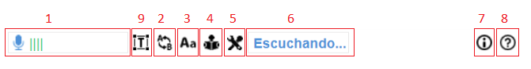

La pantalla principal de la aplicación le ofrece las siguientes opciones:

## 1. Micrófono y entrada de volumen

Esta opción tiene dos funcionalidades. Por una parte ofrece información de los posibles estados del micrófono y el volumen que está recibiendo y, por otro, permite alternar entre un estado de “Pausa” y “Escuchando”.

Adicionalmente, la barra de control de volumen indicará la entrada de sonido al micrófono. Es de destacar que si en este control de sonido se muestra un nivel muy alto, el control pasará de verde a rojo, siendo esto indicativo de que el sonido puede llegar distorsionado. Este hecho podría provocar un reconocimiento menos preciso, de ahí que sea altamente recomendable realizar una configuración de micrófono (5).

Por último, este botón permite alternar entre un estado de “Pausa” y “Escuchando”, pero nunca desde un estado no disponible.

## 2. Sustituciones

Esta opción le permite crear comandos de voz que escribirán un texto predefinido cada vez que usted los diga. Es especialmente útil cuando se escriben ciertos párrafos de texto con mucha frecuencia como, por ejemplo, una dirección, un encabezado, un pie de página o un diagnóstico que se repite.

Mediante esta herramienta podrá crear sus propios comandos de voz, indicando una orden de activación (por ejemplo “mi dirección”) y un texto que se escribirá al escuchar dicha orden (p. ej. “C/ Benito Pérez Galdós. 30110. Murcia.”).

Esta funcionalidad se explica más detalladamente en la sección Pantalla de Sustituciones.

## 3. Diccionario

En muchos dominios el lenguaje evoluciona muy rápidamente por lo que cabe la posibilidad de que aparezcan nuevos términos o siglas. Con esta herramienta usted podrá agregar nuevos términos al diccionario, indicando además si los quiere compartir con el resto de usuarios.

Es altamente aconsejable que las nuevas palabras estén acompañadas de su pronunciación correspondiente.

Esta funcionalidad se explica más detalladamente en la sección Pantalla de Diccionario.

## 4. Entrenamiento

Esta herramienta permite adaptar el sistema de reconocimiento de voz a su propia voz de forma que se obtenga una mayor precisión a la hora de reconocer el dictado.

Se trata de una opción muy relevante, por lo que le animamos a que realice entrenamientos periódicos de voz para mejorar la calidad de sus informes. Es recomendable llevar a cabo dos entrenamientos antes de empezar a usar la aplicación para el dictado de informes.

En cualquier caso, INVOX Medical Web Editor también aprenderá de los informes que dicta por lo que, con el tiempo, el sistema funcionará con un porcentaje de acierto muy elevado y no necesitará realizar más entrenamientos.

Es destacable que este entrenamiento se adapta al sonido que recoge desde el micrófono, por lo que es primordial realizar previamente una configuración de micrófono (5).

## 5. Configuración de micrófono

Esta herramienta ajusta el volumen de entrada del micrófono.

Se recomienda hacer este ajuste la primera vez que utilice el sistema y también cuando haya cambios en el tipo de micrófono que utiliza o en las condiciones de ruido ambiente de la sala en la que dicta, o previamente a realizar un entrenamiento, siendo almacenado para no tener que repetirlo cada vez que se haga uso de la aplicación.

## 6. Barra de estado

Esta barra informa del estado del editor. Los posibles valores que puede mostrar son los siguientes.

[output not shown]

[output not shown]

Descargando el perfil de usuario, por favor espere unos segundos

La aplicación se encuentra actualizando los recursos lingüísticos.

[output not shown]

El dictado se encuentra pausado

El editor espera un cambio al estado escuchando.

[output not shown]

Escuchando…

El editor se encuentra preparado para el dictado.

[output not shown]

Transcripción fonética

El editor se encuentra realizando una transcripción para una pronunciación.

[output not shown]

Corrigiendo

El editor se encuentra corrigiendo una palabra.

[output not shown]

Deletreando…

El editor no acepta dictado libre, solo las palabras especificadas para el deletreo.

[output not shown]

Guardando información de usuario

[output not shown]

Sesión iniciada correctamente. Iniciando reconocimiento de voz

[output not shown]

Seleccionar todo el texto

Ejemplo de mensaje al llamar a un comando.

[output not shown]

Sustitución “Compatible ATBG”

Ejemplo de mensaje al llamar a una sustitución.

[output not shown]

No se ha encontrado micrófono, habilite uno y recargue la página.

El editor no localiza ningún micrófono conectado al equipo.

[output not shown]

Esperando acceso al micrófono web.

El editor requiere permiso de acceso al micrófono web. En este caso aparecerá un rectángulo para aceptar dicho permiso, al cual le podrá indicar que dicho permiso se recuerde.

[output not shown]

Credenciales de usuario inválidas.

Sus datos de inicio de sesión son inválidos.

[output not shown]

Número de usuarios concurrentes superado.

Su licencia no permite la conexión de tantos usuarios simultáneamente.

[output not shown]

Sesión en otra ventana. Esperando reconexión.

Existe una segunda conexión en otra ventana, se procederá a una reconexión en un tiempo no superior a 5 segundos.

[output not shown]

Error de conexión, guarde el texto de la página y refresque pulsando F5.

Indica que ha ocurrido un error desconocido en la conexión.

[output not shown]

Error al cargar el componente Flash, revise los permisos de su navegador

Es muy posible que su configuración de seguridad no esté permitiendo la ejecución de código Flash en esta página, revise los permisos.

[output not shown]

Su sesión ha sido invalidada. Reconectando…

La sesión a la que intenta conectarse ha sido invalidado por inactividad o por un intento de conexión a la misma.

[output not shown]

La conexión de red con el servidor es inestable.

Su conexión de red es lenta.

[output not shown]

Error al iniciar el reconocimiento de voz.

No consigue iniciar el reconocimiento de voz. Este fallo es causado por un error en la instalación. Si dispone del servicio INVOX Medical Agent, reinstálelo.

[output not shown]

No se ha podido conectar con el servicio de dictado

En el caso de usar el servicio INVOX Medical Agent significa que no consigue conectar con él. En otro caso, no consigue establecer una sesión con el servidor remoto (irrecuperable).

## 7. Acerca de

Esta botón mostrará información sobre el versionado de esta aplicación como se muestra a continuación.

[figure not shown]

## 8. Ayuda

Este botón mostrará esta página de ayuda.

## 9. Transformaciones de texto

En algunas ocasiones deseará que el texto dictado se transforme de forma automática en otro texto, por ejemplo, para introducir siglas o abreviaturas en sus informes y hacerlos más concisos. Por ejemplo, supongamos que quiere que cada vez que dicta “lóbulo superior izquierdo” en su informe se escriba ‘L.S.I.’. Una opción sería dictar la sigla ‘L.S.I.’ letra a letra pero la funcionalidad de transformaciones de texto le permite dictar la sigla de forma extendida y, automáticamente, escribirla en su forma abreviada.

Esta funcionalidad difiere del uso de plantillas de texto en que no requiere de una breve pausa para aplicarse.

La forma en la que se crean, editan y eliminan estas transformaciones se encuentra descrita en la pantalla de transformaciones de texto

## Guía rápida

1. Asegúrese de que su micrófono está correctamente conectado y en la barra de estado indica **El dictado se encuentra pausado.** junto a un micrófono gris.
2. Si es la primera vez que utiliza INVOX Medical Web Editor, haga clic en la opción *Configuración de Micrófono* (5) para que se adapte a las condiciones acústicas del entorno, y tras realizarla, se aconseja realizar un **Entrenamiento** (4).
3. Para comenzar a dictar pulse el botón Dictar, utilice el comando de voz *Iniciar dictado* (o alguno de sus sinónimos). Este comando de voz estará deshabilitado si está haciendo uso del servicio **INVOX Medical Agent**, el cual permitirá hacer uso del botón de grabación para realizar esta funcionalidad de iniciar/parar dictado.
4. Una vez que el dictado esté activo (micrófono azul) puede comenzar a dictar. Puede pausar el dictado en cualquier momento volviendo a hace clic en el botón del micrófono, haciendo uso del comando de voz *Detener dictado*, o con el botón físico del micrófono si se dan las condiciones anteriores.

## Comandos

La mayoría de opciones de INVOX Medical Web Editor pueden ser controladas usando únicamente la voz. De esta forma, usted podrá iniciar y parar el reconocimiento, seleccionar párrafos o incluso moverse entre ellos haciendo uso de comandos de voz, eliminando así la necesidad de estar frente a la pantalla y ofreciendo una mayor movilidad, por ejemplo, mientras hace uso del instrumental médico al mismo tiempo que redacta el informe.

### Comandos para iniciar/parar el dictado

Para usar estas funcionalidades deberá conocer los siguientes comandos:

| Para | Diga esto |
| --- | --- |
| Iniciar el reconocedor de voz | *Iniciar dictado* |
| Detener el reconocedor de voz | *Detener dictado* |

Recuerde que estos comandos de voz se complementan con las otras opciones disponibles para iniciar y parar el reconocimiento comentadas anteriormente, es decir, utilizar el botón con el icono del micrófono en la barra de dictado.

Es de destacar que con el fin de que no se inicie o pare el dictado al escuchar algún ruido que reconozca como uno de estos comandos, en el caso de hacer uso del servicio **INVOX Medical Agent** estos comandos se encontrarán deshabilitados.

### Comandos para trabajar mientras se está dictando (no requieren de pausa)

Se trata de un conjunto de comandos que se pueden llamar mientras se está dictando. Estos comandos se muestran en la siguiente tabla.

| Para | Diga esto |
| --- | --- |
| Insertar un salto de línea en el documento | *Nueva línea* |
| Insertar un párrafo nuevo en el documento | *Nuevo párrafo* |
| Activar el de mayúsculas | *Activar mayúsculas* |
| Desactivar el bloqueo de mayúsculas | *Desactivar mayúsculas* |
| Escribir todas las palabras con la primera letra mayúscula | *Activar mayúsculas iniciales* |
| Deshabilitar el comando anterior | *Desactivar mayúsculas iniciales* |
| Escribir la siguiente palabra con la primera letra mayúscula | Mayúsculas |
| Detener el reconocedor de voz | *Detener dictado* |

### Signos de puntuación y caracteres especiales (no requieren de pausa)

INVOX Medical Web Editor permite la inserción de signos de puntuación y otros caracteres por medio de comandos de voz. El uso de estos es equivalente a llamar a un comando y no requieren de una pausa antes de llamar al comando, por lo que se pueden intercalar mientras dicta un informe.

Los distintos signos de puntuación y caracteres disponibles aparecen en la siguiente tabla:

| Para | Diga esto | Para | Diga esto |
| --- | --- | --- | --- |
| , | *Coma* | + | *Signo más* |
| ; | *Punto y coma* | { | *Abrir llave* |
| . | *Punto* | } | *Cerrar llave* |
| . | *Punto y aparte* | [ | *Abrir corchete* |
| : | *Dos puntos* | ] | *Cerrar corchete* |
| “ | *Abrir comillas* | \| | *Barra vertical* |
| ” | *Cerrar comillas ; Cerrar comilla* | :-) | *Cara sonriente* |
| ’ | *Apóstrofo* | :-( | *Cara triste* |
| ‘ | *Abrir comilla simple* | ™ | *Signo de marca comercial* |
| ’ | *Cerrar comilla simple* | ¾ | *Signo de tres cuartos* |
| > | *Signo mayor que* | ¼ | *Signo de un cuarto* |
| < | *Signo menor que* | ½ | *Signo de un medio* |
| / | *Barra* | £ | *Signo de libra* |
| @ | *Arroba* | & | *Y comercial* |
| ¡ | *Abrir admiración ; Abrir exclamación* | * | *Asterisco* |
| ! | *Cerrar admiración ; Cerrar exclamación ; Signo de admiración ; Signo de exclamación* | < | *Abrir corchete angular* |
| ¿ | *Abrir interrogación* | > | *Cerrar corchete angular* |
| ? | *Cerrar interrogación ; Signo de interrogación* | ± | *Signo más menos* |
| # | *Signo de número* | « | *Abrir comillas angulares* |
| $ | *Signo de dólar* | » | *Cerrar comillas angulares* |
| % | *Signo de porcentaje* | ÷ | *Signo de división* |
| ( | *Abrir paréntesis* | ¢ | *Signo de céntimo* |
| ) | *Cerrar paréntesis* | § | *Signo de párrafo* |
| - | *Guión ; Signo guión ; Signo menos* | ° | *Signo de grado* |
| = | *Signo igual* | … | *Puntos suspensivos ; Punto punto punto* |

### Comandos precedidos de pausa

Además de los comandos anteriores, se podrá hacer uso de un gran número de comandos, pero estos han de ir precedidos de una breve pausa. Estos comandos los divideremos a continuación en varias secciones.

Es de destacar que los comandos actuan sobre la posición actual del cursor, por lo que si algún comando se aplica sobre palabras cualquiera del dictado se aplicará sobre aquella que coincida y se encuentre lo más cercana al cursor. Estos comandos están marcados a continuación con un asterisco.

#### Comandos de formato

INVOX Medical Web Editor permite el uso de comandos que faciliten el formateo del documento. A continuación se describen estos comandos.

| Para | Diga esto |
| --- | --- |
| Insertar una tabulación | *Tabulación* |
| Poner en minúsculas todas las letras de la palabra | *Sin mayúsculas “palabra”* |
| Poner en mayúscula la primera letra de una palabra | *Mayúsculas “palabra”* |
| Poner en mayúsculas todas las letras de la palabra | *Todo mayúsculas “palabra”* |
| Poner en mayúsculas el texto seleccionado | *Mayúsculas* |
| Poner en minúsculas el texto seleccionado considerando las reglas de puntuación | *Minúsculas* |
| Activar el texto en negrita | *Activar negrita* |
| Desactivar el texto en negrita | *Desactivar negrita* |
| Activar el texto en cursiva | *Activar cursiva ; Activar itálica* |
| Desactivar el texto en cursiva | *Desactivar cursiva ; Desactivar itálica* |
| Activar el subrayado | *Activar subrayado ; Activar subrayar* |
| Desactivar el subrayado | *Desactivar subrayado ; Desactivar subrayar* |
| Abrir una lista enumerada | *Abrir lista ; Iniciar lista ; Empezar lista ; Comenzar lista* |
| Abrir una lista ordenada | *Abrir lista ordenada ; Iniciar lista ordenada ; Empezar lista ordenada ; Comenzar lista ordenada* |
| Cerrar lista (ordenada o enumerada) | *Cerrar lista ; Salir de la lista* |

#### Comandos de navegación en el informe

INVOX Medical Web Editor permite el uso de comandos que faciliten la navegación en el documento. A continuación se describen estos comandos.

| Para | Diga esto |
| --- | --- |
| Colocar el cursor antes de una palabra específica | *Ir a “palabra”* |
| Colocar el cursor después de una palabra específica | *Ir detrás de “palabra”* |
| Ir al inicio de la oración en la que se encuentra el cursor | *Ir al inicio de la oración ; Ir al principio de la oración ; Ir al inicio de la frase ; Ir al principio de la frase* |
| Ir al principio del párrafo en el que se encuentra el cursor | *Ir al inicio del párrafo ; Ir al principio del párrafo* |
| Ir al inicio del documento | *Ir al inicio del documento ; Ir al principio del documento* |
| Ir al final de la oración en la que se encuentra el cursor | *Ir al final de la oración ; Ir al final de la frase* |
| Ir a la oración anterior a la que el cursor está situado | *Ir a la oración anterior ; Ir a la frase anterior ; Ir a la anterior oración ; Ir a la anterior frase* |
| Ir a la oración siguiente a la que el cursor está situado | *Ir a la oración siguiente ; Ir a la frase siguiente ; Ir a la siguiente oración ; Ir a la siguiente frase* |
| Ir al final del párrafo en el que se encuentra el cursor | *Ir al final del párrafo* |
| Ir al final del documento actual | *Ir al final del documento* |
| Ir al párrafo anterior al que se encuentra el cursor | *Ir al anterior párrafo ; Ir al párrafo anterior* |
| Ir al párrafo siguiente al que se encuentra el cursor | *Ir al siguiente párrafo ; Ir al párrafo siguiente* |

#### Comandos de selección de texto

INVOX Medical Web Editor permite el uso de comandos que faciliten la selección en el documento. Estos comandos son los siguientes.

| Para | Diga esto |
| --- | --- |
| Seleccionar una palabra del documento actual | *Seleccionar “palabra”* |
| Seleccionar todo el texto del documento actual | *Seleccionar todo ; Seleccionar todo el texto* |
| Seleccionar la anterior oración | *Seleccionar la oración anterior ; Seleccionar la anterior oración ; Seleccionar la frase anterior ; Seleccionar la anterior frase ; Seleccionar frase ; Seleccionar oración* |
| Seleccionar la siguiente oración | *Seleccionar la oración siguiente ; Seleccionar la frase siguiente ; Seleccionar la siguiente oración ; Seleccionar la siguiente frase* |
| Seleccionar el siguiente párrafo | *Seleccionar el siguiente párrafo ; Seleccionar el párrafo siguiente* |
| Seleccionar el párrafo anterior | *Seleccionar el párrafo anterior ; Seleccionar el anterior párrafo ; Seleccionar párrafo* |
| Desactivar la selección actual | *Desactivar selección ; Deseleccionar* |

#### Comandos de eliminación de texto

INVOX Medical Web Editor permite el uso de comandos que faciliten la eliminación de texto en el documento. Estos comandos son los siguientes

| Para | Diga esto |
| --- | --- |
| Eliminar la oración anterior | *Eliminar oración anterior ; Eliminar anterior oración ; Eliminar la oración anterior ; Eliminar la anterior oración ; Eliminar la frase anterior ; Eliminar la anterior frase* |
| Eliminar la oración siguiente | *Eliminar oración siguiente ; Eliminar siguiente oración ; Eliminar la oración siguiente ; Eliminar la siguiente oración ; Eliminar la frase siguiente ; Eliminar la siguiente frase* |
| Eliminar el párrafo anterior | *Eliminar párrafo anterior ; Eliminar anterior párrafo ; Eliminar el párrafo anterior ; Eliminar el anterior párrafo* |
| Eliminar el párrafo siguiente | *Eliminar párrafo siguiente ; Eliminar siguiente párrafo ; Eliminar el párrafo siguiente ; Eliminar el siguiente párrafo* |
| Borrar la selección actual | *Borrar selección ; Eliminar selección ; Borrar ; Eliminar* |

#### Otros comandos

| Para | Diga esto |
| --- | --- |
| Corregir la palabra en la que se situa el cursor | *Corregir* |
| Corregir una palabra dictada | *Corregir “palabra”* |
| Deshacer el último cambio sobre el documento | *Deshacer* |
| Rehacer el último cambio sobre el documento | *Rehacer* |
| Escribir una cifra con números romanos | *Romanos cifra* o *Romano cifra* o *Cifra romano* |

## Uso del comando *Corregir*

Con el comando **Corregir** podrá solucionar errores en la transcripción sin necesidad de utilizar el teclado.

Para usar este comando simplemente debe decir **corregir** seguido por la palabra o palabras que desea modificar, o decir **corregir** sobre la palabra que desea corregir. INVOX Medical Web Editor seleccionará automáticamente la palabra o palabras a corregir y mostrará una lista de opciones para sustituirlas.

Si la palabra que desea no se encuentra en la lista mostrada podrá dictarla para que aparezcan una serie de alternativas. En la siguiente imagen se muestra la apariencia de la ventana de corrección que vamos a detallar con un ejemplo.

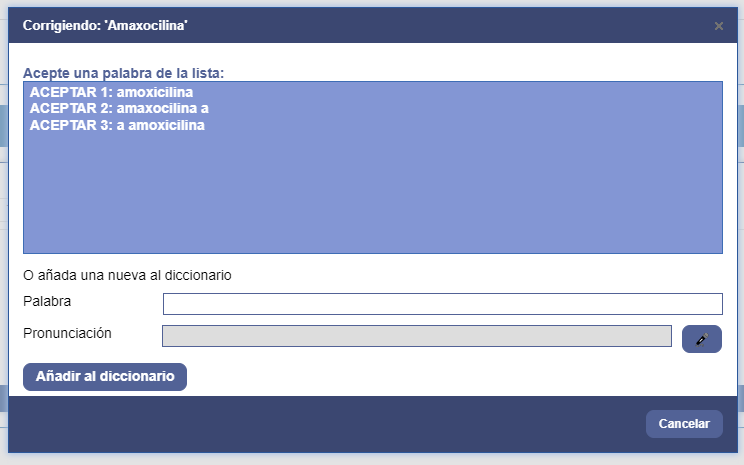

Si quiere aceptar la opción 1, puede desde hacer clic en dicha opción o hacer uso del comando por voz **ACEPTAR UNO**.

Si quiere cerrar esta ventana, además de los botones **Cancelar** y **Cerrar**, tiene el comando por voz **Cancelar**.

Si la correción que desea no aparece en la lista puede decirla para que INVOX Medical Web Editor actualice la lista de opciones. Si la palabra no está en el diccionario del sistema puede añadirla junto con su pronunciación usando la opción **Añadir al diccionario**.

Puede darse el caso de que la palabra que quiere corregir aparezca varias veces en el texto. En estos casos INVOX Medical Web Editor corregirá la más cercana al cursor.

Si realiza una corrección, el sistema intentará realizar un aprendizaje si dispone del audio anterior, y así reducir el uso que haga de esta herramienta de corrección en un futuro.

## Pantalla de sustituciones

Las sustituciones le permitirán crear comandos de voz que tendrán un texto predefinido asociado. Cada vez que diga ese comando el texto asociado se escribirá automáticamente en el documento.

Estas sustituciones le servirán, por ejemplo, para evitar tener que repetir textos que aparecen con frecuencia como una dirección, un encabezado o una parte de un diagnóstico clínico que siempre se describe de la misma forma.

Por ejemplo, imagine que desea que cada vez que diga **Compatible ATBG** se escriba el texto *Colon, biopsia: transformación adenomatosa focal compatible con adenoma tubular con displasia de bajo grado*. Para conseguir esto, utilice la opción **Sustituciones** del menú principal y pulse **Nueva sustitución** para definirla en la forma en la que se muestra en la siguiente imagen:

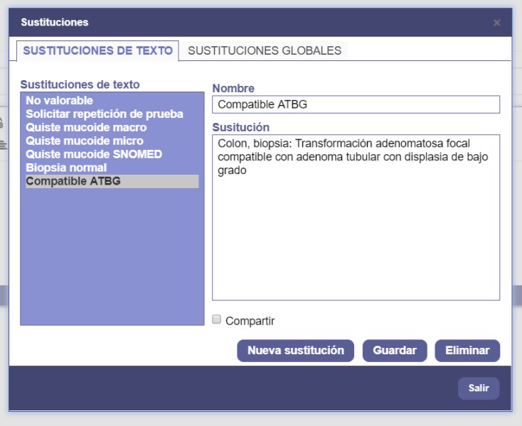

Al pulsar el botón de **Guardar**, la sustitución quedará almacenada de forma que cada vez que diga **Compatible ATBG** mientras dicta INVOX Medical Web Editor insertará automáticamente el texto de sustitución que definió. Además, si marca la opción **Compartir**, su sustitución estará disponible para el resto de usuarios de su misma especialidad de forma que el listado de sustituciones irá creciendo porque podrá usar sustituciones útiles definidas por sus compañeros y compartir con ellos las que usted defina. Es de destacar que sus sustituciones tendrán preferencia sobre las globales.

Es importante tener en cuenta que para hacer uso de la sustitución para que se escriba el texto definido, debe hacer una breve pausa en el dictado antes de decir el nombre de la misma. Es decir, si dictamos el texto “muestra obtenida compatible ATBG”, el sistema escribirá esta frase literalmente sin efectuar ninguna sustitución. Si queremos que realice la sustitución tendremos que hacer una breve pausa antes de decir su nombre, es decir, diríamos “muestra obtenida” haríamos una pequeña pausa y a continuación diríamos “compatible ATBG”. En este caso INVOX Medical Web Editor escribirá el texto de sustitución correspondiente.

Las sustituciones pueden modificarse o eliminarse pulsando los botones **Guardar** o **Eliminar** respectivamente.

## Pantalla de diccionario

INVOX Medical Web Editor incluye por defecto recursos lingüísticos para su especialidad médica pero, además, le permite ampliarlos gestionando su propio diccionario de palabras. A continuación se detallan las posibilidades que les ofrece la opción **Diccionario** del menú principal.

### Añadir palabra

Con esta opción puede añadir terminología específica que el sistema no reconozca y que utilice en sus informes. Al añadir una palabra la aplicación le pedirá que la escriba. Una vez la haya escrito tendrá la opción de introducir la pronunciación correspondiente a esa palabra con el botón del micrófono y/o almacenarla en el sistema directamente con la opción de **Guardar**.

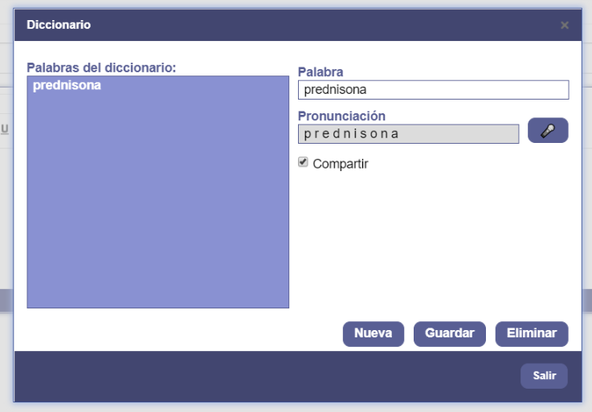

Si desea introducir una pronunciación, pulse el icono de micrófono y pronuncie la palabra.

### Compartir palabras

Cuando añadimos una nueva palabra, el sistema permite añadirla a un diccionario global de su especialidad. Esta funcionalidad permite compartir palabras entre sus compañeros de especialidad, complementando los recursos de INVOX Medical Web Editor, mejorando el sistema conforme se usa y haciendo que reconozca terminología que inicialmente no se incluía en el sistema.

Para añadir una nueva palabra al diccionario global simplemente debe marcar la opción “Compartir” al introducir una nueva palabra.

## Deletreo de palabras

INVOX Medical Web Editor permite el deletreo de palabras letra a letra, una funcionalidad que puede resultarle útil para escribir palabras que todavía no estén en el diccionario y, sobre todo, para deletrear siglas y acrónimos. Los comandos para activar y desactivar el modo de deletreo de palabras son:

| Para | Diga esto |
| --- | --- |
| Activar el modo de deletreo | *Activar deletreo* |
| Desactivar el modo de deletreo | *Desactivar deletreo* |

Una vez activado este modo puede empezar a deletrear de la forma habitual, es decir, letra a letra o también usar las palabras que aparecerán en la ventana de ayuda mostrada a continuación que aparecerá automáticamente en pantalla y que servirán para dictar cada letra del abecedario. Así, si decimos “Antonio” INVOX Medical Web Editor escribirá la letra “a”. Si decimos “Antonio mayúscula” escribirá la letra “A”.

| Para | Diga esto | Para | Diga esto | Para | Diga esto |
| --- | --- | --- | --- | --- | --- |
| a | Antonio | j | José | s | Sábado |
| b | Burgos | k | Kilo | t | Toledo |
| c | Carmen | l | Lorenzo | u | Ulises |
| c | Chocolate | m | Madrid | v | Valencia |
| d | Dolores | n | Navarra | w | Washington |
| e | España | ñ | Ñoño | x | Xilófono |
| f | Francia | o | Oviedo | y | Yegua |
| g | Granada | p | París | z | Zaragoza |
| h | Historia | q | Queso |  |  |
| i | Inés | r | Ramón |  |  |

Por ejemplo, si quiere escribir el acrónimo PSA puede decir “PE ESE A” (modo letra a letra) o “París Sábado Antonio”.

Puede utilizar los siguiente comandos:

- Deshacer
- Rehacer
- Activar mayúsculas
- Desactivar mayúsculas
- Tabulación

Recuerde que la opción “Diccionario” le permite añadir nuevas palabras y siglas junto con la pronunciación que desee para ellas así que es la opción adecuada para dar de alta nuevas palabras y siglas que aparezcan con frecuencia evitando tener que deletrearlas cada vez que aparezcan.

## Pantalla de transformaciones de texto

Esta sección describe como definir, modificar y eliminar transformaciones de texto con las que podrá sustituir de forma automática un texto dictado por un texto resultado. En la siguiente figura se muestra un ejemplo de transformación de texto por el que tras dictar ‘lóbulo superior izquierdo’ se escribirá ‘L.S.I.’

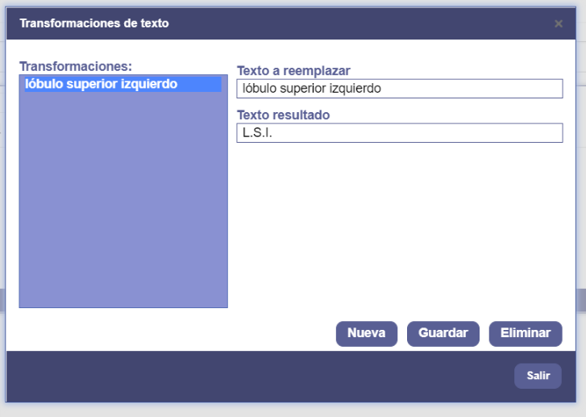

Estas transformaciones se añaden de la misma forma que las nuevas palabras o sustituciones. Para ello, hacemos clic en ‘Nueva’, indicamos en la caja ‘Texto a reemplazar’ el texto que dictaremos y en la caja ‘Texto resultado’ el texto que queremos que se escriba al dictar ese texto. Tras esto será necesario guardar los cambios haciendo clic en ‘Guardar’. Es importante destacar que la búsqueda del texto a reemplazar no es sensible a mayúsculas y minúsculas y que solamente afecta a palabras completas (es decir, si queremos transformar *lóbulo* en *L* solo se aplicacará la transformación para la palabra *lóbulo* pero no para *lóbulos*).

También es posible modificar transformaciones editando los valores de cada caja de texto y, finalmente, guardando las modificaciones. Para eliminar una transformación selecciónela y haga clic en ‘Eliminar’ (en este caso se eliminará directamente, es decir, sin pedir confirmación y sin que sea necesario guardar los cambios).

# Preguntas Frecuentes en INVOX Medical Web Editor (F.A.Q)

**El espaciado cada vez que pulso ‘enter’ es muy amplio ¿Se puede reducir?** > Al pulsar ‘enter’ se crea un nuevo párrafo, con un espaciado distinto a una nueva linea, de forma similar a editores como OpenOffice o Word, esto sirve para poder diferenciar entre un párrafo y una nueva línea, por lo que si quiere introducir un salto de línea puede pulsar la combinación de teclas ‘shift+enter’.

**Algunas veces desaparece el cursor, ¿qué ha pasado?** > Actualmente no hemos podido solventar este problema, pues depende de una aplicación externa. Aún no apareciendo el cursor, este debe estar localizado y escribir desde en la última posición vista. Se puede recuperar la visión de este haciendo un clic sobre el editor.

**No me reconoce bien, ¿cómo se podría mejorar esto?** > Tal vez el problema esté asociado a una mala **configuración de micrófono** o a que no se ha realizado el **entrenamiento**. Si el problema es que faltan algunos términos puede añadirlos, e incluso compartirlos con sus compañeros, a traves de la herramienta **Diccionario**.

**¿Es necesario hacer la configuración de micrófono a diario?** > No, almacenamos los resultados de configuraciones de micrófono para su usuario, aunque si es cierto que si detecta un cambio de ruido ambiental o un cambio de micrófono es altamente aconsejable realizar la configuración de nuevo.

**¿Y el entrenamiento?** > Al igual que en la configuración de volumen del micrófono, los valores se almacenan y se recuperan al iniciar sesión. Si no ha realizado una configuración de micrófono para su micrófono y condiciones de ruido ambiental, es necesario realizarla antes del entrenamiento.

**¿Se pueden pegar mis propias plantillas/templates por comando de voz?** > Sí, para ello podrá hacer uso de la herramienta **Sustituciones**. Adicionalmente podrá compartir sus sustituciones con el resto de sus compañeros y, en el caso de que haya un conflicto por nombres, se priorizará el uso de su sustitución personal en lugar de la compartida.

**¿Y puedo dar formato a las sustituciones, por ejemplo, usando negritas?** > No, actualmente no disponemos de esa funcionalidad.

**Acabo de eliminar parte del documento, ¿puedo recuperarlo?** > Es posible que pueda recuperarlo haciendo uso del comando **deshacer** ya sea como comando de voz **Deshacer/Rehacer**, haciendo uso de la combinación de teclas **Ctrl+Z** o haciendo clic en el botón asociado a esta funcionalidad en la barra de INVOX Medical Web Editor.

**He dejado activas las mayúsculas y ahora todo el informe está en mayúsculas, ¿cómo puedo ponerlo en minúsculas?** > Tiene dos opciones. Por una parte puede hacer clic en el botón correspodiente **aa** el cual convertirá a minúsculas el texto seleccionado, o usar el comando de voz **Minúsculas** que actuará de igual forma al botón. Es de destacar que esta funcionalidad tiene en cuenta detalles sintácticos como signos de puntuación, pero no los detalles semánticos como siglas o nombres propios.

**¿Qué comandos hay disponibles?** > La lista de comandos está disponible en la sección de ayuda de INVOX Medical Web Editor.

**No me funcionan los comandos ‘Iniciar dictado’ y ‘Detener dictado’ aunque haga pausas** > Si tiene conectado al equipo un micrófono de mano que disponga de botones y este es capaz de iniciar y detener dictado por medio de estos botones, entonces los comandos de voz **Iniciar dictado** y **Detener dictado** estarán deshabilitados.

**He estado probando los comandos y en vez de realizar lo que dicen, lo escriben** > La mayor parte de los comandos a excepción de algunos como **Activar mayúsculas** o **nueva linea** requieren de una pausa previa al comando. En el caso de los comandos que requieran de palabras del informe como *Corregir radiografía* es posible que los escriba aún habiendo realizado una pausa si no encuentra radiografía o la aplicación no es capaz de entender *radiografía*.

**¿Para qué sirve la opción “Compartir” de diccionario y sustituciones?** > Con esta funcionalidad usted es capaz de ofrecer sus palabras y sustituciones al resto de compañeros para su especialidad en su lugar de trabajo.

**La barra de volumen se mueve, pero no me reconoce nada** > Es muy probable que el dictado se encuentre pausado, lo cual se indica con un micrófono gris. Solo hay que iniciar el dictado con cualquiera de las formas disponibles, ya sea haciendo clic en el icono del micrófono, usando el comando ‘Iniciar dictado’ o, en el caso de que este comando esté deshabilitado, haciendo uso del botón del micrófono.

**¿Se puede convertir un texto en sus siglas de forma automática?** > Sí, para ello deberá hacer uso de la funcionalidad de transformaciones de texto